# Выделение групп пользователей мобильного приложения на основе поведения

## Введение

Цель данного исследования - изучить поведение и сегментировать пользователей мобильного приложения "Ненужные вещи". В нем пользователи продают свои ненужные вещи, размещая их на доске объявлений.

### Декомпозиция

1. Выгрузка и изучение данных
2. Предобработка данных
   - Приведение названий колонок к общему стилю
   - Изменение типов данных
   - Поиск и удаление дубликатов
   - Поиск и заполнение пропусков
   - Объединение типов событий
   - Создание столбцов с id и временем сессии
3. Изучение общего поведения пользователей
   - Удержание
   - Время, проведенное в приложении
   - Частота использования приложения
   - Конверсия в целевое действие
4. Сегментация пользователей
5. Ответы на основные вопросы
   - Группа с более высоким retention rate
   - Группа с более высокой конверсией в целевое действие
6. Проверка статистических гипотез
   - Сравнение конверсии пользователей, пришедших из Yandex и Google
   - Сравнение медианного времени сессии в группах пользователей с лучшей и худшей конверсией
7. Выводы

## Выгрузка и изучение данных

Импортируем все необходимые библиотеки.

```python
import pandas as pd
from datetime import datetime, timedelta
import numpy as np
import matplotlib.pyplot as plt
import seaborn as sns
from scipy import stats as st
from statsmodels.stats.proportion import proportions_ztest
```

```python
sourсes = pd.read_csv('/mobile_soures.csv')
events = pd.read_csv('/mobile_dataset.csv')
```

Изучим доступные датасеты.

**Описание данных:**

Датасет содержит данные о событиях, совершенных в мобильном приложении "Ненужные вещи". В датасете содержатся данные пользователей, впервые совершивших действия в приложении после 7 октября 2019 года.

Датасет **mobile_dataset.csv** содержит колонки:

- `event.time` — время совершения
- `event.name` — название события
- `user.id` — идентификатор пользователя

Датасет **mobile_sources.csv** содержит колонки:

- `userId` — идентификатор пользователя
- `source` — источник, с которого пользователь установил приложение

Расшифровки событий:

- `advert_open` — открытие карточки объявления
- `photos_show` — просмотр фотографий в объявлении
- `tips_show` — пользователь увидел рекомендованные объявления
- `tips_click` — пользователь кликнул по рекомендованному объявлению
- `contacts_show` и `show_contacts` — пользователь нажал на кнопку "посмотреть номер телефона" на карточке объявления
- `contacts_call` — пользователь позвонил по номеру телефона на карточке объявления
- `map` — пользователь открыл карту размещенных объявлений
- `search_1` — `search_7` — разные события, связанные с поиском по сайту
- `favorites_add` — добавление объявления в избранное

```python
sourсes.head()
```

|  | userId | source |
| --- | --- | --- |
| 0 | 020292ab-89bc-4156-9acf-68bc2783f894 | other |
| 1 | cf7eda61-9349-469f-ac27-e5b6f5ec475c | yandex |
| 2 | 8c356c42-3ba9-4cb6-80b8-3f868d0192c3 | yandex |
| 3 | d9b06b47-0f36-419b-bbb0-3533e582a6cb | other |
| 4 | f32e1e2a-3027-4693-b793-b7b3ff274439 | google |

```python
events.head()
```

|  | event.time | event.name | user.id |
| --- | --- | --- | --- |
| 0 | 2019-10-07 00:00:00.431357 | advert_open | 020292ab-89bc-4156-9acf-68bc2783f894 |
| 1 | 2019-10-07 00:00:01.236320 | tips_show | 020292ab-89bc-4156-9acf-68bc2783f894 |
| 2 | 2019-10-07 00:00:02.245341 | tips_show | cf7eda61-9349-469f-ac27-e5b6f5ec475c |
| 3 | 2019-10-07 00:00:07.039334 | tips_show | 020292ab-89bc-4156-9acf-68bc2783f894 |
| 4 | 2019-10-07 00:00:56.319813 | advert_open | cf7eda61-9349-469f-ac27-e5b6f5ec475c |

```python
sourсes.info()
```

```
<class 'pandas.core.frame.DataFrame'>
RangeIndex: 4293 entries, 0 to 4292
Data columns (total 2 columns):
 #   Column  Non-Null Count  Dtype
---  ------  --------------  -----
 0   userId  4293 non-null   object
 1   source  4293 non-null   object
dtypes: object(2)
memory usage: 67.2+ KB
```

```python
events.info()
```

```
<class 'pandas.core.frame.DataFrame'>
RangeIndex: 74197 entries, 0 to 74196
Data columns (total 3 columns):
 #   Column      Non-Null Count  Dtype
---  ------      --------------  -----
 0   event.time  74197 non-null  object
 1   event.name  74197 non-null  object
 2   user.id     74197 non-null  object
dtypes: object(3)
memory usage: 1.7+ MB
```

```python
print('Пользователей в датафрейме events:', events['user.id'].unique().size)
```

```
Пользователей в датафрейме events: 4293
```

Количество уникальных пользователей в датафреймах совпадает, их 4293. За период произошли 74197 событий.

```python
print('Начало периода:', events['event.time'].min())
print('Окончание периода:', events['event.time'].max())
```

```
Начало периода: 2019-10-07 00:00:00.431357
Окончание периода: 2019-11-03 23:58:12.532487
```

Доступны данные с 7 октября по 3 ноября 2019 года.

```python
sourсes['source'].unique()
```

```
array(['other', 'yandex', 'google'], dtype=object)
```

В данных есть три источника - Яндекс, Гугл и остальные.

```python
print('Типов событий:', events['event.name'].unique().size)
print(events['event.name'].unique())
```

```
Типов событий: 16
['advert_open' 'tips_show' 'map' 'contacts_show' 'search_4' 'search_5'
 'tips_click' 'photos_show' 'search_1' 'search_2' 'search_3'
 'favorites_add' 'contacts_call' 'search_6' 'search_7' 'show_contacts']
```

Всего в датасете 16 различных типов событий.

## Предобработка данных

### Приведение названий столбцов к общему стилю

```python
sourсes.columns = ['user_id', 'source']
events.columns = events.columns.str.replace('.', '_', regex=False)
```

```python
display(sourсes.columns, events.columns)
```

```
Index(['user_id', 'source'], dtype='object')
```

```
Index(['event_time', 'event_name', 'user_id'], dtype='object')
```

Стиль названий столбцов унифицирован.

### Изменение типов данных

Приведем столбец с временем события к типу datetime.

```python
events['event_time'] = pd.to_datetime(events['event_time'])
```

### Объединение типов событий

Различия в типах событий search не играют роли в этом исследовании, поэтому объединим их.

```python
events.loc[events['event_name'].str.contains('search'), 'event_name'] = 'search'
```

Объединим также типы contacts_show и show_contacts.

```python
events.loc[events['event_name'].str.contains('show_contacts'), 'event_name'] = 'contacts_show'
events['event_name'].unique()
```

```
array(['advert_open', 'tips_show', 'map', 'contacts_show', 'search',
       'tips_click', 'photos_show', 'favorites_add', 'contacts_call'],
      dtype=object)
```

Объединение прошло успешно.

### Поиск и удаление дубликатов

Проверим данные на дубликаты.

```python
print('Дубликаты в sourсes:', sourсes.duplicated().sum())
print('Дубликаты в events:', events.duplicated().sum())
```

```
Дубликаты в sourсes: 0
Дубликаты в events: 0
```

Округлим время события до секунд.

```python
events['event_time'] = events['event_time'].dt.round("S")
print('Дубликаты в events:', events.duplicated().sum())
```

```
Дубликаты в events: 1190
```

Вряд ли пользователь совершал сразу несколько действий одного типа в секунду. Вероятно, дело в случайных нажатиях или ошибках при сборе данных. Удалим дубликаты.

```python
print('Доля дубликатов:', '{0:.2%}'.format(events.duplicated().sum() / events['user_id'].count()))
events = events.drop_duplicates().reset_index(drop=True)
```

```
Доля дубликатов: 1.60%
```

Проверим отдельно столбец user_id в датафрейме sources, поскольку там должны содержаться лишь уникальные значения.

```python
print('Дубликаты в user_id:', sourсes['user_id'].duplicated().sum())
```

```
Дубликаты в user_id: 0
```

Дубликатов не обнаружено.

### Поиск и заполнение пропусков

Теперь изучим пропуски.

```python
sourсes.isna().sum()
```

```
user_id    0
source     0
dtype: int64
```

```python
events.isna().sum()
```

```
event_time    0
event_name    0
user_id       0
dtype: int64
```

Пропусков не обнаружено. Данные выгружены качественно.

### Создание столбцов с id и временем сессии

Для дальнейшего исследования нам понадобится время сессий пользователей и разбиение событий на сессии для каждого пользователя.

```python
events = events.sort_values(['user_id', 'event_time'])
# определяем разницу в 20/30/40 минут для каждой группы с помощью кумулятивной суммы
time_frames = ['20Min', '30Min', '40Min', '50Min']
for i in time_frames:
    g = (events.groupby('user_id')['event_time'].diff() > pd.Timedelta(i)).cumsum()
    events['session_id'] = events.groupby(['user_id', g], sort=False).ngroup() + 1
    print('Сессий c отсутсвием активности {}:'.format(i), events['session_id'].unique().size)
```

```
Сессий c отсутсвием активности 20Min: 10975
Сессий c отсутсвием активности 30Min: 10368
Сессий c отсутсвием активности 40Min: 10029
Сессий c отсутсвием активности 50Min: 9776
```

Выберем условием окончания сессии отсутсвие активности пользователя в течение 30 минут. Если увеличивать этот период еще больше, то количество сессий прибавится незначительно, а шанс получить ошибочно объединенные в сессию события выше.

```python
g = (events.groupby('user_id')['event_time'].diff() > pd.Timedelta('30Min')).cumsum()
events['session_id'] = events.groupby(['user_id', g], sort=False).ngroup() + 1
print('Сессий:'.format(i), events['session_id'].unique().size)
```

```
Сессий: 10368
```

Мы получили 10368 сессий. Теперь добавим столбцы с их началом и окончанием, а также вычислим их длительность в секундах. Создадим столбец с датой события.

```python
events['session_start'] = events.groupby('session_id')['event_time'].transform(min)
events['session_end'] = events.groupby('session_id')['event_time'].transform(max)
events['session_duration'] = (events['session_end'] - events['session_start']).dt.seconds
events['event_dt'] = events['event_time'].dt.date
events
```

|  | event_time | event_name | user_id | session_id | session_start | session_end | session_duration | event_dt |
| --- | --- | --- | --- | --- | --- | --- | --- | --- |
| 795 | 2019-10-07 13:39:46 | tips_show | 0001b1d5-b74a-4cbf-aeb0-7df5947bf349 | 1 | 2019-10-07 13:39:46 | 2019-10-07 13:49:42 | 596 | 2019-10-07 |
| 796 | 2019-10-07 13:40:31 | tips_show | 0001b1d5-b74a-4cbf-aeb0-7df5947bf349 | 1 | 2019-10-07 13:39:46 | 2019-10-07 13:49:42 | 596 | 2019-10-07 |
| 799 | 2019-10-07 13:41:06 | tips_show | 0001b1d5-b74a-4cbf-aeb0-7df5947bf349 | 1 | 2019-10-07 13:39:46 | 2019-10-07 13:49:42 | 596 | 2019-10-07 |
| 810 | 2019-10-07 13:43:21 | tips_show | 0001b1d5-b74a-4cbf-aeb0-7df5947bf349 | 1 | 2019-10-07 13:39:46 | 2019-10-07 13:49:42 | 596 | 2019-10-07 |
| 818 | 2019-10-07 13:45:31 | tips_show | 0001b1d5-b74a-4cbf-aeb0-7df5947bf349 | 1 | 2019-10-07 13:39:46 | 2019-10-07 13:49:42 | 596 | 2019-10-07 |
| ... | ... | ... | ... | ... | ... | ... | ... | ... |
| 71415 | 2019-11-03 15:51:24 | tips_show | fffb9e79-b927-4dbb-9b48-7fd09b23a62b | 10368 | 2019-11-03 15:36:01 | 2019-11-03 16:08:25 | 1944 | 2019-11-03 |
| 71420 | 2019-11-03 15:51:58 | contacts_show | fffb9e79-b927-4dbb-9b48-7fd09b23a62b | 10368 | 2019-11-03 15:36:01 | 2019-11-03 16:08:25 | 1944 | 2019-11-03 |
| 71506 | 2019-11-03 16:07:41 | tips_show | fffb9e79-b927-4dbb-9b48-7fd09b23a62b | 10368 | 2019-11-03 15:36:01 | 2019-11-03 16:08:25 | 1944 | 2019-11-03 |
| 71510 | 2019-11-03 16:08:18 | tips_show | fffb9e79-b927-4dbb-9b48-7fd09b23a62b | 10368 | 2019-11-03 15:36:01 | 2019-11-03 16:08:25 | 1944 | 2019-11-03 |
| 71511 | 2019-11-03 16:08:25 | tips_show | fffb9e79-b927-4dbb-9b48-7fd09b23a62b | 10368 | 2019-11-03 15:36:01 | 2019-11-03 16:08:25 | 1944 | 2019-11-03 |

73007 rows × 8 columns

Также создадим датафрейм sessions с данными о пользовательских сессиях.

```python
sessions = (
            events.sort_values(by=['session_id', 'session_start'])
            .groupby('session_id', as_index=False)
            .agg(
                { # возьмем первые значения и подсчитаем количество событий в сессии
                    'user_id': 'first',
                    'session_start': 'first',
                    'session_end': 'count',
                    'session_duration': 'first',
                    'event_name': 'first',

                }
            )
        )

# добавим столбцы с датой, годом, месяцем и неделей сессии
sessions['dt'] = sessions['session_start'].dt.date
sessions['year'] = sessions['session_start'].dt.year
sessions['month'] = sessions['session_start'].dt.month
sessions['week'] = sessions['session_start'].astype('datetime64[W]').dt.date
sessions = sessions.merge(sourсes, on='user_id').rename(columns={'session_end': 'events'})

sessions
```

|  | session_id | user_id | session_start | events | session_duration | event_name | dt | year | month | week | source |
| --- | --- | --- | --- | --- | --- | --- | --- | --- | --- | --- | --- |
| 0 | 1 | 0001b1d5-b74a-4cbf-aeb0-7df5947bf349 | 2019-10-07 13:39:46 | 9 | 596 | tips_show | 2019-10-07 | 2019 | 10 | 2019-10-03 | other |
| 1 | 2 | 0001b1d5-b74a-4cbf-aeb0-7df5947bf349 | 2019-10-09 18:33:56 | 4 | 507 | map | 2019-10-09 | 2019 | 10 | 2019-10-03 | other |
| 2 | 3 | 0001b1d5-b74a-4cbf-aeb0-7df5947bf349 | 2019-10-21 19:52:31 | 14 | 899 | tips_show | 2019-10-21 | 2019 | 10 | 2019-10-17 | other |
| 3 | 4 | 0001b1d5-b74a-4cbf-aeb0-7df5947bf349 | 2019-10-22 11:18:15 | 8 | 758 | map | 2019-10-22 | 2019 | 10 | 2019-10-17 | other |
| 4 | 5 | 00157779-810c-4498-9e05-a1e9e3cedf93 | 2019-10-19 21:34:34 | 9 | 1521 | search | 2019-10-19 | 2019 | 10 | 2019-10-17 | yandex |
| ... | ... | ... | ... | ... | ... | ... | ... | ... | ... | ... | ... |
| 10363 | 10364 | fffb9e79-b927-4dbb-9b48-7fd09b23a62b | 2019-11-02 01:16:49 | 1 | 0 | tips_show | 2019-11-02 | 2019 | 11 | 2019-10-31 | google |
| 10364 | 10365 | fffb9e79-b927-4dbb-9b48-7fd09b23a62b | 2019-11-02 18:01:27 | 2 | 974 | tips_show | 2019-11-02 | 2019 | 11 | 2019-10-31 | google |
| 10365 | 10366 | fffb9e79-b927-4dbb-9b48-7fd09b23a62b | 2019-11-02 19:25:54 | 4 | 296 | tips_show | 2019-11-02 | 2019 | 11 | 2019-10-31 | google |
| 10366 | 10367 | fffb9e79-b927-4dbb-9b48-7fd09b23a62b | 2019-11-03 14:32:56 | 15 | 948 | tips_show | 2019-11-03 | 2019 | 11 | 2019-10-31 | google |
| 10367 | 10368 | fffb9e79-b927-4dbb-9b48-7fd09b23a62b | 2019-11-03 15:36:01 | 14 | 1944 | tips_show | 2019-11-03 | 2019 | 11 | 2019-10-31 | google |

10368 rows × 11 columns

Проверим, есть ли сессии с нулевой длительностью.

```python
print('Сессий с нулевой длительностью:', sessions[sessions['session_duration'] == 0]['session_id'].count())
print('Доля таких сессий:', '{0:.2%}'.format(sessions[sessions['session_duration'] == 0]['session_id'].count() / sessions['session_id'].count()))
```

```
Сессий с нулевой длительностью: 2142
Доля таких сессий: 20.66%
```

Скорее всего, эти сессии завершились ошибкой, если только событием не был показ объявления или открытие объявления. Удалим такие сессии.

```python
sessions = sessions.query('session_duration > 0 or event_name in ["tips_show", "advert_open"]')
print('Сессий с нулевой длительностью:', sessions[sessions['session_duration'] == 0]['session_id'].count())
print('Доля таких сессий:', '{0:.2%}'.format(sessions[sessions['session_duration'] == 0]['session_id'].count() / sessions['session_id'].count()))
```

```
Сессий с нулевой длительностью: 945
Доля таких сессий: 10.30%
```

Удалены более половины таких сессий.

Зададим функции, необходимые для анализа.

Создание пользовательских профилей:

```python
def get_profiles(sessions):

    profiles = (
        sessions.sort_values(by=['user_id', 'session_start'])
        .groupby('user_id', as_index=False)
        .agg(
            {
                'events': 'sum',
                'session_id': 'count',
                'session_start': 'first',
                'session_duration': 'median',
                'source': 'first',
                'dt': 'first',
                'week': 'first',
            }

        )
        .rename(columns={'session_start': 'first_ts', 'session_id': 'sessions'})
    )

    return profiles
```

Расчет удержания пользователей:

```python
def get_retention(
    profiles,
    sessions,
    observation_date,
    horizon_days,
    dimensions=[],
    ignore_horizon=False,
):

    # исключаем пользователей, не «доживших» до горизонта анализа
    last_suitable_acquisition_date = observation_date
    if not ignore_horizon:
        last_suitable_acquisition_date = observation_date - timedelta(
            days=horizon_days - 1
        )
    result_raw = profiles.query('dt <= @last_suitable_acquisition_date')

    # собираем «сырые» данные для расчёта удержания
    result_raw = result_raw.merge(
        sessions[['user_id', 'session_start']], on='user_id', how='left'
    )
    result_raw['lifetime'] = (
        result_raw['session_start'] - result_raw['first_ts']
    ).dt.days

    if len(dimensions) == 0:
        result_raw['cohort'] = 'All users'
        dimensions = dimensions + ['cohort']

    # рассчитываем удержание
    result_grouped = result_raw.pivot_table(
        index=dimensions,
        columns='lifetime',
        values='user_id',
        aggfunc='nunique',
    )
    cohort_sizes = (
        result_raw.groupby(dimensions)
        .agg({'user_id': 'nunique'})
        .rename(columns={'user_id': 'cohort_size'})
    )
    result_grouped = cohort_sizes.merge(
        result_grouped, on=dimensions, how='left'
    ).fillna(0)
    result_grouped = result_grouped.div(result_grouped['cohort_size'], axis=0)

    # исключаем все лайфтаймы, превышающие горизонт анализа
    result_grouped = result_grouped[
        ['cohort_size'] + list(range(horizon_days))
    ]

    # восстанавливаем столбец с размерами когорт
    result_grouped['cohort_size'] = cohort_sizes

    # возвращаем таблицу удержания и сырые данные
    return result_raw, result_grouped
```

Расчет конверсии:

```python
def get_conversion(
    profiles,
    purchases,
    observation_date,
    horizon_days,
    dimensions=[],
    ignore_horizon=False,
):

    # исключаем пользователей, не «доживших» до горизонта анализа
    last_suitable_acquisition_date = observation_date
    if not ignore_horizon:
        last_suitable_acquisition_date = observation_date - timedelta(
            days=horizon_days - 1
        )
    result_raw = profiles.query('dt <= @last_suitable_acquisition_date')

    # определяем дату и время первой покупки для каждого пользователя
    first_purchases = (
        purchases.sort_values(by=['user_id', 'event_time'])
        .groupby('user_id')
        .agg({'event_time': 'first'})
        .reset_index()
    )

    # добавляем данные о покупках в профили
    result_raw = result_raw.merge(
        first_purchases[['user_id', 'event_time']], on='user_id', how='left'
    )

    # рассчитываем лайфтайм для каждой покупки
    result_raw['lifetime'] = (
        result_raw['event_time'] - result_raw['first_ts']
    ).dt.days

    # группируем по cohort, если в dimensions ничего нет
    if len(dimensions) == 0:
        result_raw['cohort'] = 'All users'
        dimensions = dimensions + ['cohort']

    # функция для группировки таблицы по желаемым признакам
    def group_by_dimensions(df, dims, horizon_days):
        result = df.pivot_table(
            index=dims, columns='lifetime', values='user_id', aggfunc='nunique'
        )
        result = result.fillna(0).cumsum(axis = 1)
        cohort_sizes = (
            df.groupby(dims)
            .agg({'user_id': 'nunique'})
            .rename(columns={'user_id': 'cohort_size'})
        )
        result = cohort_sizes.merge(result, on=dims, how='left').fillna(0)
        # делим каждую «ячейку» в строке на размер когорты
        # и получаем conversion rate
        result = result.div(result['cohort_size'], axis=0)
        result = result[['cohort_size'] + list(range(horizon_days))]
        result['cohort_size'] = cohort_sizes
        return result

    # получаем таблицу конверсии
    result_grouped = group_by_dimensions(result_raw, dimensions, horizon_days)

    # для таблицы динамики конверсии убираем 'cohort' из dimensions
    if 'cohort' in dimensions:
        dimensions = []

    # получаем таблицу динамики конверсии
    result_in_time = group_by_dimensions(
        result_raw, dimensions + ['dt'], horizon_days
    )

    # возвращаем обе таблицы и сырые данные
    return result_raw, result_grouped, result_in_time
```

Сглаживание фрейма:

```python
def filter_data(df, window):
    # для каждого столбца применяем скользящее среднее
    for column in df.columns.values:
        df[column] = df[column].rolling(window).mean()
    return df
```

Визуализация удержания:

```python
def plot_retention(retention, retention_history, horizon, window=7):

    # задаём размер сетки для графиков
    plt.figure(figsize=(15, 8))

    # исключаем размеры когорт и удержание первого дня
    retention = retention.drop(columns=['cohort_size', 0])
    # в таблице динамики оставляем только нужный лайфтайм
    retention_history = retention_history.drop(columns=['cohort_size'])[
        [horizon - 1]
    ]

    # в таблице графиков — два столбца и две строки, четыре ячейки
    # в первой строим кривые удержания платящих пользователей
    ax1 = plt.subplot(2, 2, 1)
    retention.T.plot(
        grid=True, ax=ax1
    )
    plt.legend()
    plt.xlabel('Лайфтайм')
    plt.title('Удержание пользователей')

    # в третьей ячейке — динамика удержания платящих
    ax2 = plt.subplot(2, 2, 2)
    # получаем названия столбцов для сводной таблицы
    columns = [
        name
        for name in retention_history.index.names
        if name not in ['dt']
    ]
    # фильтруем данные и строим график
    filtered_data = retention_history.pivot_table(
        index='dt', columns=columns, values=horizon - 1, aggfunc='mean'
    )
    filter_data(filtered_data, window).dropna().plot(grid=True, ax=ax2)
    plt.xlabel('Дата привлечения')
    plt.title(
        'Динамика удержания пользователей на {}-й день'.format(
            horizon
        )
    )
    plt.xticks(rotation = 45)
    plt.tight_layout()
    plt.show()
```

Визуализация конверсии:

```python
def plot_conversion(conversion, conversion_history, horizon, window=7):

    # задаём размер сетки для графиков
    plt.figure(figsize=(15, 5))

    # исключаем размеры когорт
    conversion = conversion.drop(columns=['cohort_size'])
    # в таблице динамики оставляем только нужный лайфтайм
    conversion_history = conversion_history.drop(columns=['cohort_size'])[
        [horizon - 1]
    ]

    # первый график — кривые конверсии
    ax1 = plt.subplot(1, 2, 1)
    conversion.T.plot(grid=True, ax=ax1)
    plt.legend()
    plt.xlabel('Лайфтайм')
    plt.title('Конверсия пользователей')

    # второй график — динамика конверсии
    ax2 = plt.subplot(1, 2, 2, sharey=ax1)
    columns = [
        # столбцами сводной таблицы станут все столбцы индекса, кроме даты
        name for name in conversion_history.index.names if name not in ['dt']
    ]
    filtered_data = conversion_history.pivot_table(
        index='dt', columns=columns, values=horizon - 1, aggfunc='mean'
    )
    filter_data(filtered_data, window).dropna().plot(grid=True, ax=ax2)
    plt.xlabel('Дата привлечения')
    plt.title('Динамика конверсии пользователей на {}-й день'.format(horizon))
    plt.xticks(rotation = 45)

    plt.tight_layout()
    plt.show()
```

Необходимые функции заданы. Можно переходить к анализу.

### Удержание пользователей

Изучим retention rate для несегментированной совокупности пользователей. Для этого создадим фрейм с профилями пользователей.

```python
profiles = get_profiles(sessions)
profiles.head()
```

|  | user_id | events | sessions | first_ts | session_duration | source | dt | week |
| --- | --- | --- | --- | --- | --- | --- | --- | --- |
| 0 | 0001b1d5-b74a-4cbf-aeb0-7df5947bf349 | 35 | 4 | 2019-10-07 13:39:46 | 677.0 | other | 2019-10-07 | 2019-10-03 |
| 1 | 00157779-810c-4498-9e05-a1e9e3cedf93 | 70 | 5 | 2019-10-19 21:34:34 | 2168.0 | yandex | 2019-10-19 | 2019-10-17 |
| 2 | 00463033-5717-4bf1-91b4-09183923b9df | 10 | 1 | 2019-11-01 13:54:35 | 1483.0 | yandex | 2019-11-01 | 2019-10-31 |
| 3 | 004690c3-5a84-4bb7-a8af-e0c8f8fca64e | 32 | 6 | 2019-10-18 22:14:06 | 956.5 | google | 2019-10-18 | 2019-10-17 |
| 4 | 00551e79-152e-4441-9cf7-565d7eb04090 | 7 | 2 | 2019-10-25 16:44:41 | 280.0 | yandex | 2019-10-25 | 2019-10-24 |

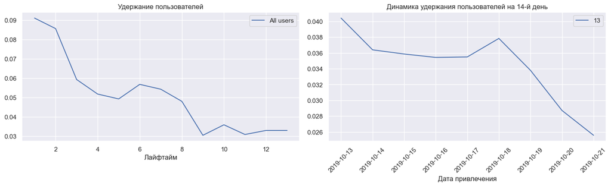

```python
# зададим тему и палитру графиков в проекте
sns.set_theme(style="darkgrid")
sns.set_palette('deep')

# рассчитываем удержание, его динамику и строим графики
retention_raw, retention = get_retention(profiles, sessions, profiles['dt'].max(), 14)
retention_raw, retention_history = get_retention(profiles, sessions, profiles['dt'].max(), 14, dimensions=['dt'])
plot_retention(retention, retention_history, 14)
```

Снижение удержания замедляется с 4-го дня жизни пользователя и прекращается после 9-го. Это значит, что оставшиеся 3% пользователей стали постоянными.

Удержание на 14-й день стабильно в первой половине графика, но стремительно падает после 18 октября. Общее падение за рассматриваемый период - с 4% до 2,6%.

Изучим удержание пользователей по неделям.

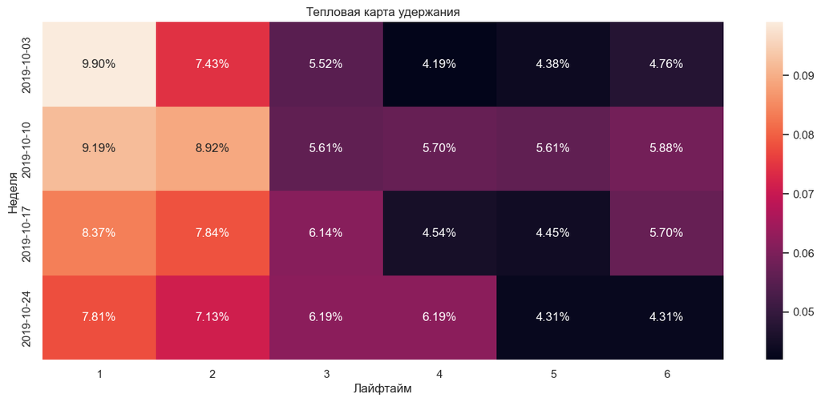

```python
retention_raw, retention = get_retention(profiles, sessions, profiles['dt'].max(), 7, 'week')

# строим хитмэп по неделям
plt.figure(figsize = (15, 6))
sns.heatmap(retention.drop(columns = ['cohort_size', 0]),
            annot = True,
            fmt = '.2%'
           )
plt.title('Тепловая карта удержания')
plt.ylabel('Неделя')
plt.xlabel('Лайфтайм')
plt.show()
```

Наилучшие показатели удержания у пользователей, пришедших на второй неделе рассматриваемого периода.

Рассмотрим удержание с разбиением по источнику, откуда пользователь загрузил приложение.

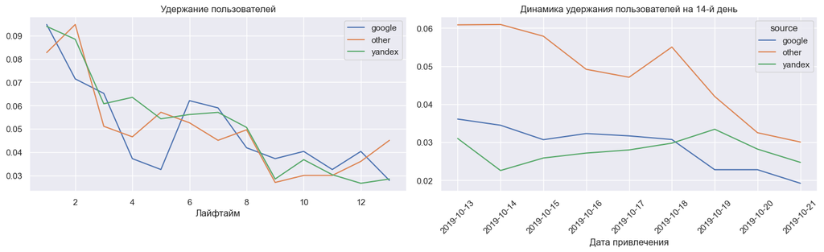

```python
retention_raw, retention = get_retention(profiles, sessions, profiles['dt'].max(), 14, dimensions=['source'])
retention_raw, retention_history = get_retention(profiles, sessions, profiles['dt'].max(), 14, dimensions=['dt', 'source'])
plot_retention(retention, retention_history, 14)
```

Удержание примерно одинаково по всем каналам. На 14-й день удержание пользователей из Гугла и Яндекса находятся примерно на одном уровне, а лучшие результаты показывают другие источники.

### Время, проведенное в приложении

Рассмотрим медианную длительность сессии в динамике.

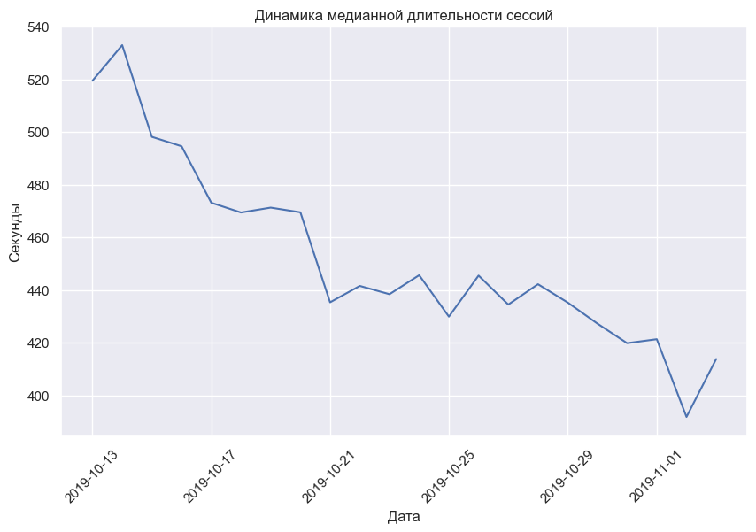

```python
report = (sessions.groupby('dt')['session_duration']
          .median()
          .rolling(7).mean() # сглаживаем данные
         )

plt.figure(figsize=(10, 6))
report.plot()
plt.title('Динамика медианной длительности сессий')
plt.xlabel('Дата')
plt.ylabel('Секунды')
plt.xticks(rotation = 45)
plt.show()
```

Медианное время сессии снижается постепенно на всем протяжении графика. С начала месяца показатель падает с 530 до 400 секунд.

Изучим среднее время, которое пользователи проводят в приложении в день.

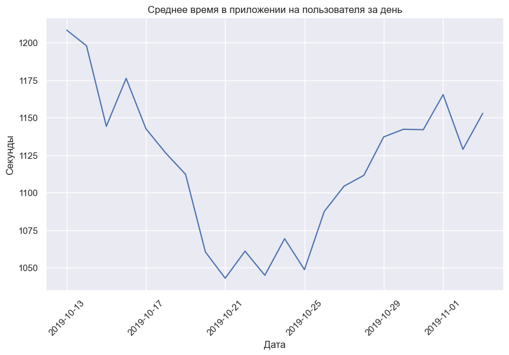

```python
report = (sessions.groupby(['dt'], as_index=False)
          .agg(n_users=('user_id','nunique'), session_duration=('session_duration', 'sum'))
         )
# делим число сессий на количество пользователей
report['duration_per_user'] = (report['session_duration'] / report['n_users'])
report['duration_per_user'] = report['duration_per_user'].rolling(7).mean()

plt.figure(figsize=(10, 6))
sns.lineplot(x=report['dt'], y=report['duration_per_user'])
plt.title('Среднее время в приложении на пользователя за день')
plt.xlabel('Дата')
plt.ylabel('Секунды')
plt.xticks(rotation=45)
plt.show()
```

Наибольшее время пользователи тратили в приложении до 16 октября - около 1175 секунд в среднем в день. В середине графика следует снижение с последующим отскоком до 1150 в конце месяца.

Рассмотрим среднюю длительность одной сессии пользователей с разбиением по дате.

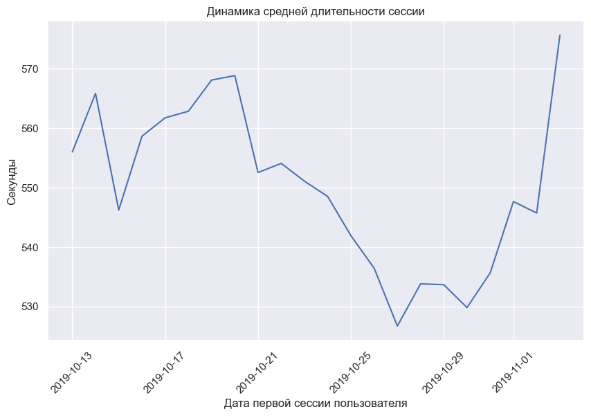

```python
report = profiles.groupby('dt', as_index=False)['session_duration'].median()
report['session_duration'] = report['session_duration'].rolling(7).mean()

plt.figure(figsize=(10, 6))
sns.lineplot(x=report['dt'], y=report['session_duration'])
plt.title('Динамика средней длительности сессии')
plt.xlabel('Дата первой сессии пользователя')
plt.ylabel('Секунды')
plt.xticks(rotation=45)
plt.show()
```

С 13 по 20 октября время колеблется в районе 550-570 секунд. С середине наблюдается падение до 530 секунд, но в конце месяца график идет резко вверх.

**Вывод.** Длительность одной сессии стабильно уменьшается. Средняя длительность сессии в когортах, пришедших в разные дни, и среднее время на пользователя колеблется примерно на одном уровне.

### Частота использования приложения

Следующая метрика - частота действий, производимых пользователями. Рассмотрим динамику событий.

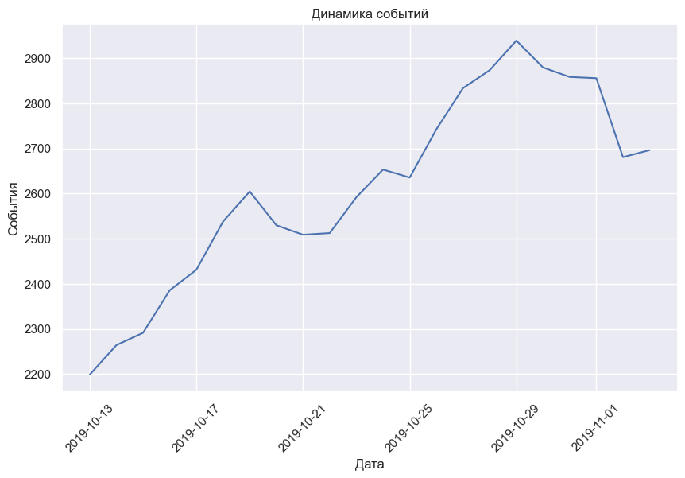

```python
ids = sessions['session_id']
events = events.query('session_id in @ids') # уберем из анализа ранее удаленные из фрейма sessions строки

plt.figure(figsize=(10, 6))
(events.groupby('event_dt')['event_name'].count()
    .rolling(7).mean()
    .plot()
)
plt.title('Динамика событий')
plt.xlabel('Дата')
plt.ylabel('События')
plt.xticks(rotation=45)
plt.show()
```

Количество событий растет в почти весь рассматриваемый период - с 2200 до 2900 в день, однако после 29 октября тренд переломился.

Посмотрим график среднего количества событий за день на одного пользователя.

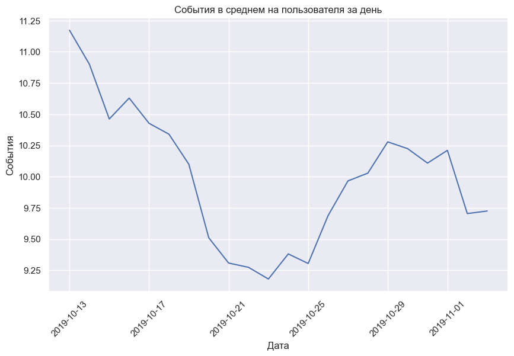

```python
report = events.groupby(['event_dt'], as_index=False).agg(
    n_events=('user_id', 'count'), n_users=('user_id', 'nunique'))

# делим число сессий на количество пользователей
report['events_per_user'] = (report['n_events'] / report['n_users'])
report['events_per_user'] = report['events_per_user'].rolling(7).mean()

plt.figure(figsize=(10, 6))
sns.lineplot(x=report['event_dt'], y=report['events_per_user'])
plt.title('События в среднем на пользователя за день')
plt.xlabel('Дата')
plt.ylabel('События')
plt.xticks(rotation=45)
plt.show()
```

Показатель нестабилен. После высоких значений в начале - свыше 11 событий, количество действий на пользователя резко упало в середине месяца до 9,25 событий с последующим отскоком до 10,25 событий и новым падением.

Количество событий растет, но среднее количество на пользователей падает. Проверим динамику количества пользователей.

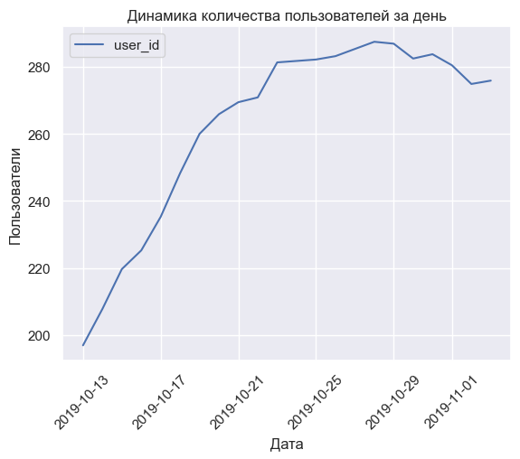

```python
plt.figure(figsize=(10, 6))

(events.groupby(['event_dt'])
     .agg({'user_id': 'nunique'})
     .rolling(7).mean()
     .plot()
)

plt.title('Динамика количества пользователей за день')
plt.xlabel('Дата')
plt.ylabel('Пользователи')
plt.xticks(rotation=45)
plt.show()
```

Среднее количество событий падает из-за роста дневного количества пользователей.

**Вывод.** Количество действий в приложении растет, но из-за более быстрого роста количества пользователей, среднее количество событий снижается.

### Конверсия в целевое действие

Исследуем конверсию пользователей. Целевое действие - это просмотр контактов.

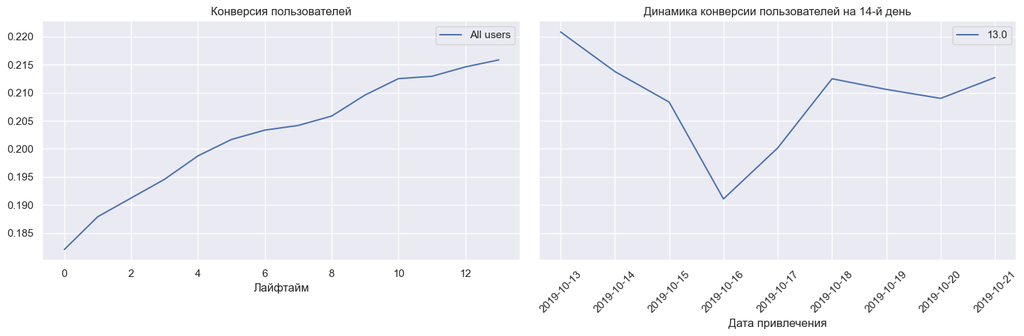

```python
contacts_show = events.query('event_name == "contacts_show"')[['user_id', 'event_time']] # создадим фрейм с целевыми событиями

conversion_raw, conversion, conversion_history = get_conversion(profiles, contacts_show, profiles['dt'].max(), 14)
plot_conversion(conversion, conversion_history, 14)
```

Конверсия по датасету на 7-й день составляет 20,5%, на 14-й - 21,5%. График динамики на 14-й день относительно стабилен, кроме сильного падения у пользователей, пришедших 16 октября.

Изучим также конверсию для разных источников.

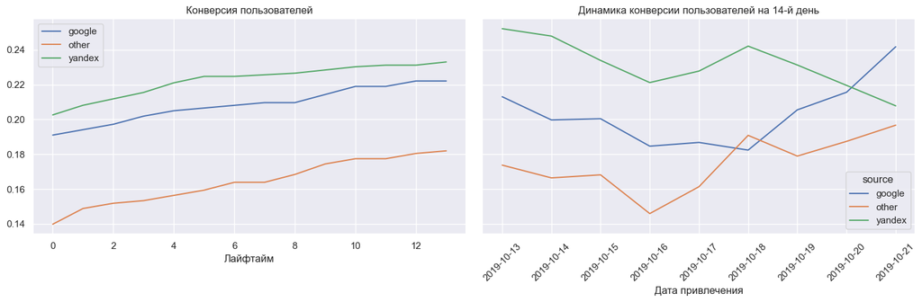

```python
conversion_raw, conversion, conversion_history = get_conversion(profiles, contacts_show, profiles['dt'].max(), 14, dimensions=['source'])
plot_conversion(conversion, conversion_history, 14)
```

Лучшую конверсию показывает группа пользователей, установивших приложение из Яндекса - конверсия на 14-й день равна 23%. Далее следует Гугл. Показатели других источников сильно хуже.

Посмотрим общую конверсию по проекту.

```python
print('Конверсия:', round(contacts_show['user_id'].unique().size / profiles['user_id'].count(), 3))
```

```
Конверсия: 0.223
```

Конверсия по всему датасету равна 22,3%.

**Вывод.**

- Удержание пользователей постоянно снижается.
- Средняя длительность сессии падает, но среднее время, проводимое пользователем в приложении за день, остается на одном уровне.
- Среднее количество событий на пользователя уменьшается, но благодаря быстрому росту аудитории, общее количество действий растет.
- Конверсия по всему датасету равна 22% и держится примерно на одном уровне весь рассматриваемый период.

## Сегментация пользователей

Было принято решение разделить пользователей на 4 группы по количеству действий, совершенных в приложении. Среди более активных пользователей, вероятно, большее удержание, и они чаще совершают целевое действие. Доработав приложение под их поведение и нужды, можно улучшить результаты.

```python
segmented_profiles = profiles.copy() # создадим отдельный фрейм

segmented_profiles['segment'] = 'D' # пользователи будут разделены по квартилям количества событий
segmented_profiles.loc[segmented_profiles['events'] > np.percentile(segmented_profiles['events'], 25), 'segment'] = 'C'
segmented_profiles.loc[segmented_profiles['events'] > np.percentile(segmented_profiles['events'], 50), 'segment'] = 'B'
segmented_profiles.loc[segmented_profiles['events'] > np.percentile(segmented_profiles['events'], 75), 'segment'] = 'A'


print('Нераспределенные пользователи:', segmented_profiles['segment'].isna().sum())
segmented_profiles['segment'].value_counts()
```

```
Нераспределенные пользователи: 0
```

```
D    1195
C    1063
A    1017
B     973
Name: segment, dtype: int64
```

Все пользователи были разделены на примерно равные сегменты по количеству совершенных событий.

## Ответы на основные вопросы

### Группа с лучшим удержанием

Изучим, пользователи какого сегмента чаще возвращаются в приложение.

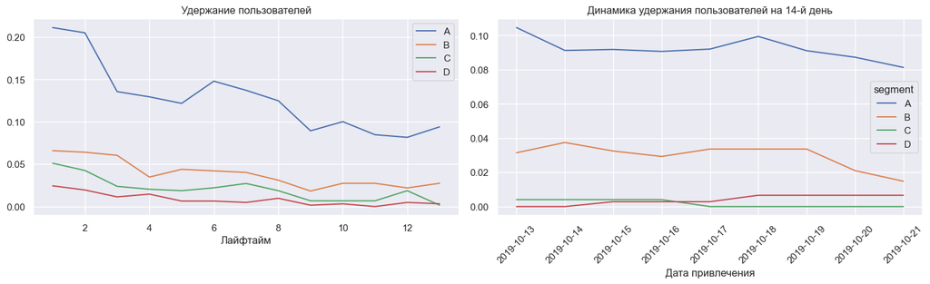

```python
retention_raw, retention = get_retention(segmented_profiles, sessions, segmented_profiles['dt'].max(), 14, dimensions=['segment'])
retention_raw, retention_history = get_retention(segmented_profiles, sessions, segmented_profiles['dt'].max(), 14, dimensions=['segment', 'dt'])
plot_retention(retention, retention_history, 14)
```

Удержание группы пользователей с самым большим количеством событий значительно выше, чем у остальных трех четвертей юзеров. Retention rate группы "B" в первый день составляет 6%, а у сегмента "А" не падает ниже 8% даже к 14 дню. Почти на всем протяжении графика удержание пользователей сегмента "D" находится около нуля.

### Группа с лучшей конверсией

Рассмотрим, пользователи какой группы чаще делают целевое событие.

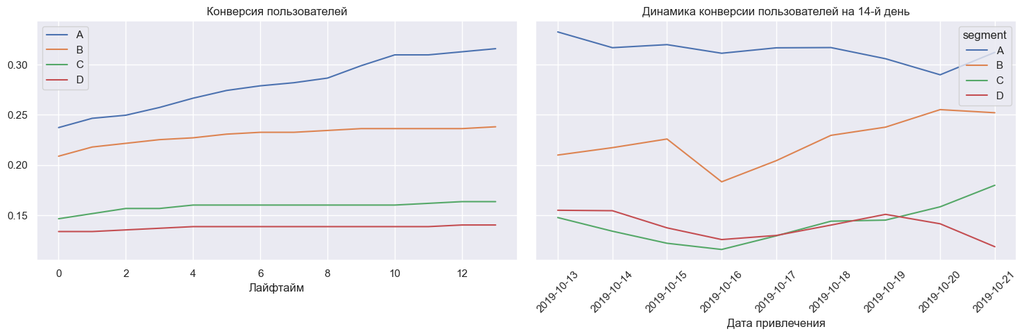

```python
conversion_raw, conversion, conversion_history = get_conversion(segmented_profiles, contacts_show, segmented_profiles['dt'].max(), 14, dimensions=['segment'])
plot_conversion(conversion, conversion_history, 14)
```

Пользователи сегмента "A" намного чаще просматривают контакты в объявлении, чем остальные, притом, чем больше лайфтайм, тем больше разница. Далее сегменты так же располагаются соответственно количеству событий у пользователей. К 14-му дню конверсия группы "А" достигает 31%, а группы "D" - 14%.

Посмотрим общую конверсию в сегментах.

```python
target_users = contacts_show['user_id']

for segment in segmented_profiles['segment'].unique():
    print('Конверсия в сегменте {}:'.format(segment),
          round(segmented_profiles.query('segment == @segment and user_id in @target_users')['user_id'].count() /
                segmented_profiles.query('segment == @segment')['user_id'].count(), 2))
```

```
Конверсия в сегменте A: 0.34
Конверсия в сегменте B: 0.24
Конверсия в сегменте C: 0.17
Конверсия в сегменте D: 0.15
```

## Проверка статистических гипотез

### Сравнение конверсии пользователей, пришедших из Yandex и Google

Некоторые пользователи установили приложение по ссылке из Yandex, другие - из Google.

Проверим, есть ли пересекающиеся пользователи.

```python
google = segmented_profiles.query('source == "google"')['user_id']
yandex = segmented_profiles.query('source == "yandex"')['user_id']

np.intersect1d(google, yandex)
```

```
array([], dtype=object)
```

Пересекающихся пользователей нет, проверяем гипотезу z-тестом.

Нулевая гипотеза: конверсия в двух этих группах равна.

Альтернативная гипотеза: две эти группы демонстрируют разную конверсию в просмотры контактов.

```python
target_google = segmented_profiles.query('source == "google" and user_id in @target_users')['user_id'].count()
target_yandex = segmented_profiles.query('source == "yandex" and user_id in @target_users')['user_id'].count()
stat, pval = proportions_ztest([target_google, target_yandex], [google.count(), yandex.count()])

print(target_google, target_yandex, google.count(), yandex.count())

alpha = 0.05 # уровень значимости

print(pval)
if pval < alpha: # условный оператор с выводом строки с ответом
    print('Отвергаем нулевую гипотезу')
else:
    print('Не получилось отвергнуть нулевую гипотезу')
```

```
268 466 1123 1914
0.7644107291802509
Не получилось отвергнуть нулевую гипотезу
```

Нулевую гипотезу отвергнуть нельзя. Это значит, что, вероятно, конверсия пользователей, пришедших из Гугла и Яндекса, равна.

### Сравнение медианного времени сессии в группах пользователей с лучшей и худшей конверсией

Нулевая гипотеза: медианное время сессии пользователей из группы с самой высокой конверсией в целевое действие равно медианному времени сессии пользователей из группы с самой низкой конверсией.

Альтернативная гипотеза: медианное время сессии пользователей из группы с самой высокой конверсией в целевое действие больше медианного времени сессии пользователей из группы с самой низкой конверсией.

```python
segment_a = segmented_profiles.query('segment == "A"')['session_duration']
segment_d = segmented_profiles.query('segment == "D"')['session_duration']

results = st.ttest_ind(segment_a, segment_d)

print(results.pvalue / 2) # делим на 2 поскольку тест односторонний
if (results.pvalue / 2 < alpha) and (segment_a.mean() > segment_d.mean()):
    print("Отвергаем нулевую гипотезу")
else:
    print("Не получилось отвергнуть нулевую гипотезу")

print(segment_a.mean() / segment_d.mean())
```

```
6.385915457309238e-122
Отвергаем нулевую гипотезу
3.708521834284955
```

## Выводы

В ходе проекта были проанализированы данные с 7 октября по 3 ноября 2019 года:

- Удержание пользователей снизилось за рассматриваемый период.
- Среднее длительность сессии упала, а среднее время за день - нет.
- Среднее количество событий уменьшается, но благодаря быстрому росту аудитории, общее количество действий растет.
- Конверсия находится примерно на одном уровне в конце и начале периода.

Пользователи были разделены на 4 группы по количеству действий, совершенных в приложении:

Были проверены 2 статистические гипотезы:

- Конверсия пользователей, пришедших из Гугла и Яндекса, не отличается.
- У пользователей группы "А" (с лучшей конверсией) медианное время больше, чем у пользователей группы "D" (с худшей).

**Презентация результатов: https://disk.yandex.ru/i/UW7aosdJC3FYaQ**